# Effect of Prosper Loan Features on Loan Amount

## by Ozavize Alabi

## Investigation Overview

Some form of correlation exist between Investors and LoanOrignalAmount, we can also observe that some form of relationship exist between StatedMonthlyIncome and LoanOriginalAmount(0.18) further inverstigation with more records and features is required to be certain.

The overall goal was to investigate how other Loan features in the data affect the loanOriginalAmount, and the distribution of the number of loans given to borrowers as per other Loan features

## Dataset Overview

This data set contains 113,937 loans with 81 variables on each loan, including loan amount, borrower rate (or interest rate), current loan status, borrower income, and many others.

## Loan Amount Distribution

The purpose is to investigate the distribution of Loan Amount. The distribution indicates tri-modality with most given loan amounts at 4000, 10000, 15000 US dollars

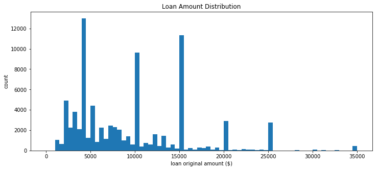

## Distribution of Stated Monthly Income

The distribution indicates that majority of the custormers have a monthly income between 2000 and 10000 US dollars with a noticable peak monthly income around 5000 dollars which would likely be the median monthly income

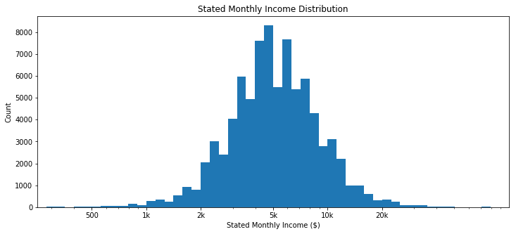

## Investors Distribution

Here i tried to investgate how the loans were distributed based the Investors variable. It can be observed that the number of investors that funded most of the loans range from 1 to about 200 in number.

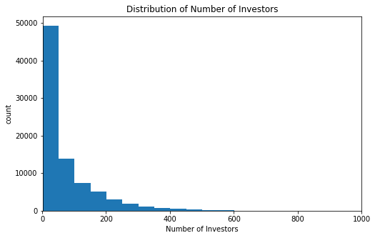

## Correlation plot of features

From the heat map we can observe that a minute positive relationship exist between Investors and LoanOriginalAmount(0.32), we can also observe that some form of relationship exist between StatedMonthlyIncome and LoanOriginalAmount(0.18) further inverstigation with more records and features is required to be certain.

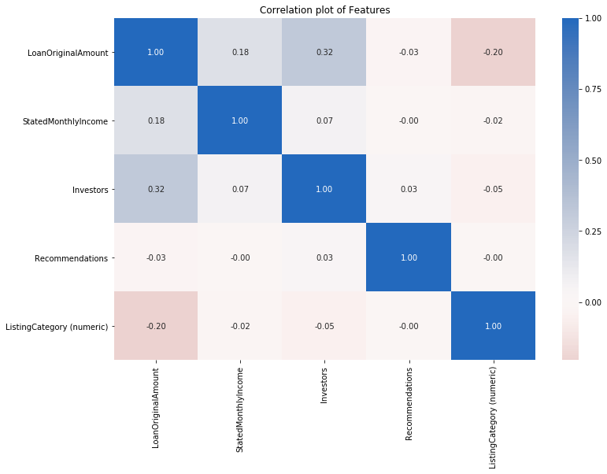

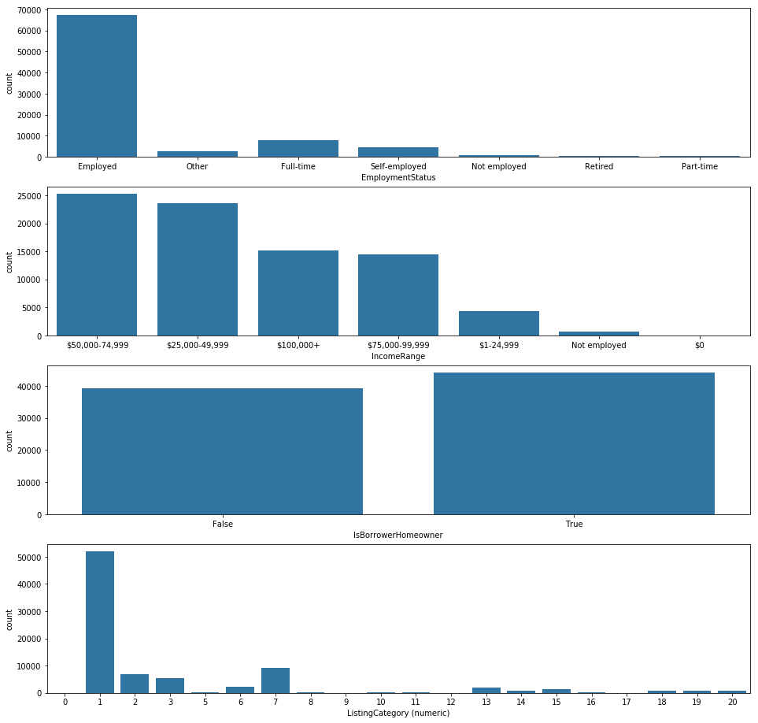